# **01 Pokèmon Data Visualization with R**

Zinni Matteo

## Background

The Complete Pokemon Dataset includes 801 Pokèmon and 41 variables from 7 generations (1996-2019). Features refer only to Pokèmon video games and not to other products such as Pokèmon GO or trading card game. The original version is available for free download at [Kaggle](https://www.kaggle.com/rounakbanik/pokemon).

## Objective

The first project within Pokémon data science is focused on data visualization as a powerful tool to give a first overview of data for further analysis. The dataset represent an interesting opportunity to display both quantitative (continuous and discrete) and qualitative variables. In this project some simple question will be graphically answered.

- item 1 Which region host the greatest number of Pokémon?
- item 2 Which is the most abundant Pokèmon type according Type 1 and Type 2

## Data cleaning

Since some variables can be considered useless for this project two column have been removed

```r
# remove ability column
pokemon = pokemon[,-1]

# remove japanese name column
pokemon = pokemon[,-29]
```

## Feature engineering

Since each Pokèmon generation belong to a different region a new feature (Region) have been creating sourcing a function that is store in the local project folder. The function makes a double check on the Pokedex_Number number and on the Generation to which the Pokémon belongs to assign the proper region name.

```r
# running function
pokemon$Region = as.factor(assign_region(pokemon))

# check levels (must be 7 just like generations)
levels(pokemon$Region)
```

```
## [1] "Alola"  "Hoenn"  "Johto"  "Kalos"  "Kanto"  "Sinnoh" "Unova"
```

## Data Visualization: discrete variable

The firs part of this project will be focused on discrete variables for which barplot represent the best choice to give some nice data visualization

### Overall abundance by regions

We want first explore the overall Pokèmon abundance. Since we will we use ggplot2 package we need to first make a table that reports the number of pokèmon for each region.

```r
# creating fist a df to pass to ggplot function
region_df = as.data.frame(table(pokemon$Region, dnn = "Region"), responseName = "Abundance")

print(region_df)
```

```
##   Region Abundance
## 1  Alola        80
## 2  Hoenn       135
## 3  Johto       100
## 4  Kalos        72
## 5  Kanto       151
## 6 Sinnoh       107
## 7  Unova       156
```

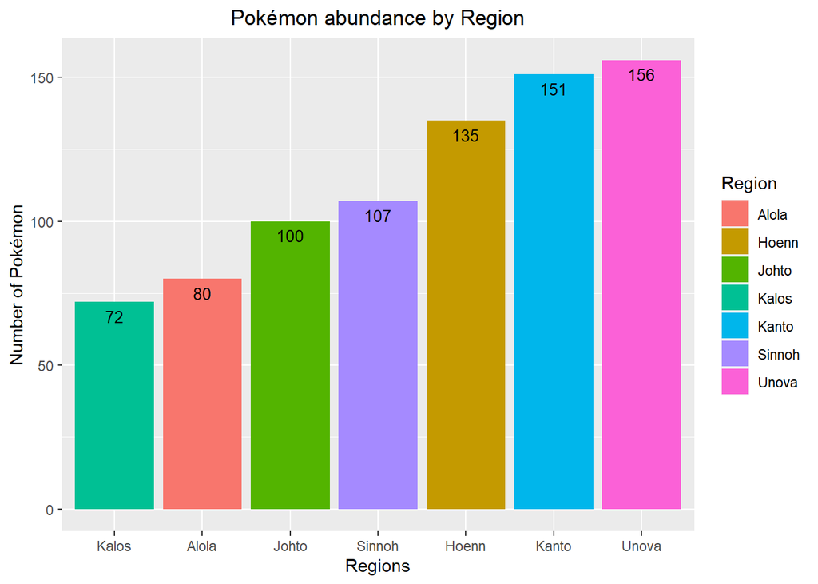

```r
# creating fist a df to pass to ggplot function
ggplot(data=region_df, aes(x= reorder(Region, Abundance), y=Abundance, fill=Region)) +
  geom_bar(stat="identity") +
  geom_text(aes(label=Abundance), vjust=1.6, color="Black", size=3.5) +
  xlab(label = "Regions") +
  ylab(label = "Number of Pokémon") +
  ggtitle(label = "Pokémon abundance by Region") +
  theme(plot.title = element_text(hjust = 0.5))
```

### Pokèmon type and composition by regions

Types refer to different elemental properties associated with both Pokémon and their moves. Each type has its own strengths and weaknesses, most of which are logical setups. Pokémon can have up to two types while their moves can only be one type. Let’s first consider Type_1 and then Type_2. It’s important to keep in mind that Type 2 may be not present: to overcome this features new level “None” for the variable Type_2 has been introduced.

```r
# Type_1 dataframe
knitr::kable(head(type_1_df))
```

| Type_1 | Region | Abundance |
| --- | --- | --- |
| Bug | Alola | 9 |
| Dark | Alola | 1 |
| Dragon | Alola | 3 |
| Electric | Alola | 3 |
| Fairy | Alola | 1 |
| Fighting | Alola | 3 |

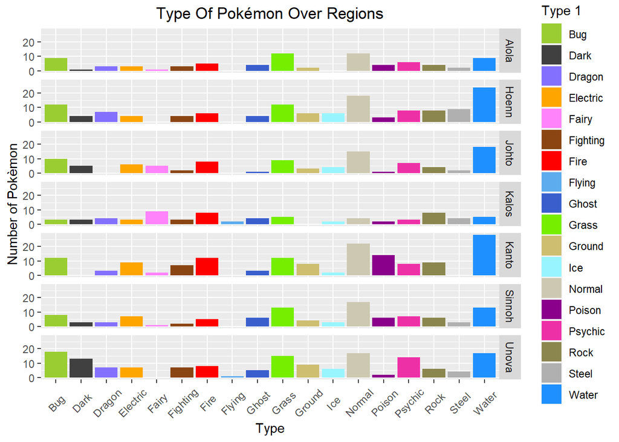

```r
# creating color vector with proper color
pokemon_type_1_color = c("yellowgreen", "gray25", "lightslateblue", "orange", "orchid1", "chocolate4", "red1", "steelblue2", "royalblue3","chartreuse2", "lightgoldenrod3", "cadetblue1", "cornsilk3", "magenta4","maroon2", "khaki4", "grey69", "dodgerblue" )

# plot
ggplot(type_1_df, aes(y = Abundance, x = Type_1 , fill = Type_1 )) +
  theme(axis.text.x = element_text(angle = 45, vjust = 0.5, hjust=0.5), plot.title = element_text(hjust = 0.5))+
  guides(fill=guide_legend(title="Type 1")) +
  geom_bar(stat = 'identity') + facet_grid(Region ~.) +
  labs(title = "Type Of Pokémon Over Regions",x="Type",y="Number of Pokèmon") +
  scale_fill_manual(values = pokemon_type_1_color)
```

```r
# Type_2 dataframe
knitr::kable(head(type_2_df))
```

| Type_2 | Region | Abundance |
| --- | --- | --- |
| None | Alola | 29 |
| Bug | Alola | 2 |
| Dark | Alola | 1 |
| Dragon | Alola | 3 |
| Electric | Alola | 2 |
| Fairy | Alola | 11 |

```r
# creating color vector with proper color
pokemon_type_2_color = c("yellowgreen", "gray25", "lightslateblue", "orange", "orchid1", "chocolate4", "red1", "steelblue2", "royalblue3", "chartreuse2", "lightgoldenrod3", "cadetblue1", "slategray","cornsilk3", "magenta4","maroon2", "khaki4", "grey69", "dodgerblue" )
```

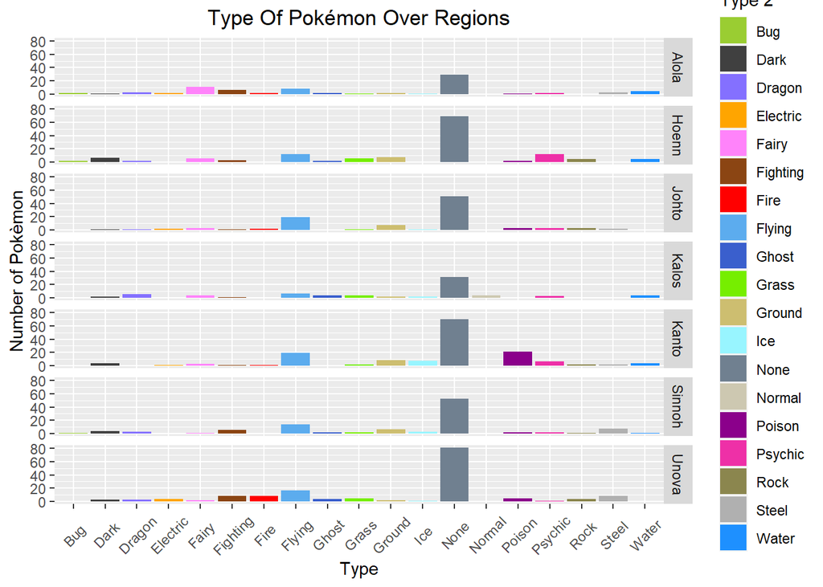

```r
# plot
ggplot(type_2_df, aes(y = Abundance, x = Type_2 , fill = Type_2 )) +
  theme(axis.text.x = element_text(angle = 45, vjust = 0.5, hjust=0.5), plot.title = element_text(hjust = 0.5))+
  guides(fill=guide_legend(title="Type 2")) +
  geom_bar(stat = 'identity') + facet_grid(Region ~.) +
  labs(title = "Type Of Pokémon Over Regions",x="Type",y="Number of Pokèmon") +
  scale_fill_manual(values = pokemon_type_2_color)
```

Since the number of pokémon differs among region, to have a more accurate overview of the Type the use of relative percentage could be more meaningfull.

```r
# calculating relative percentage of type composition (Type 1)
type_1_df$Relative_abundance = round(((type_1_df$Abundance/rep(region_df$Abundance, each = length(levels(type_1_df$Type_1))))*100),2)

# check df
knitr::kable(head(type_1_df))
```

| Type_1 | Region | Abundance | Relative_abundance |
| --- | --- | --- | --- |
| Bug | Alola | 9 | 11.25 |
| Dark | Alola | 1 | 1.25 |
| Dragon | Alola | 3 | 3.75 |
| Electric | Alola | 3 | 3.75 |
| Fairy | Alola | 1 | 1.25 |
| Fighting | Alola | 3 | 3.75 |

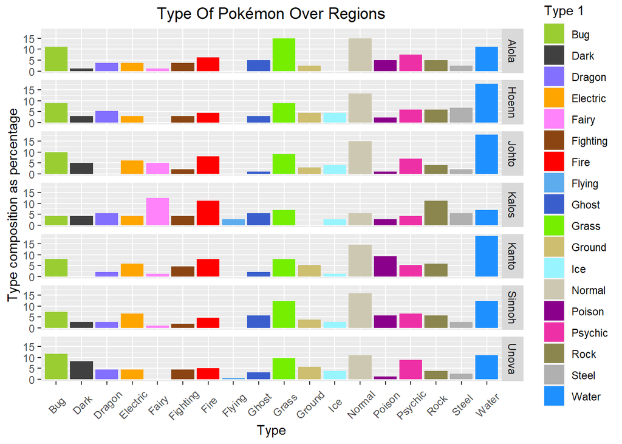

```r
# plot
ggplot(type_1_df, aes(y = Relative_abundance, x = Type_1 , fill = Type_1 )) +
  theme(axis.text.x = element_text(angle = 45, vjust = 0.5, hjust=0.5), plot.title = element_text(hjust = 0.5))+
  guides(fill=guide_legend(title="Type 1")) +
  geom_bar(stat = 'identity') + facet_grid(Region ~.) +
  labs(title = "Type Of Pokémon Over Regions",x="Type",y="Type composition as percentage") +
  scale_fill_manual(values = pokemon_type_1_color)
```

```r
# calculating relative percentage of type composition (Type 2)
type_2_df$Relative_abundance = round(((type_2_df$Abundance/rep(region_df$Abundance, each = length(levels(type_2_df$Type_2))))*100),2)
```

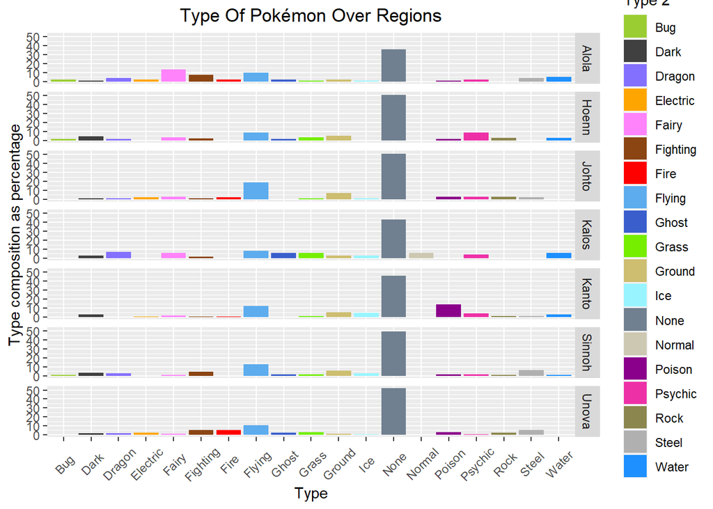

```r
# plot
ggplot(type_2_df, aes(y = Relative_abundance, x = Type_2 , fill = Type_2 )) +
  theme(axis.text.x = element_text(angle = 45, vjust = 0.5, hjust=0.5), plot.title = element_text(hjust = 0.5))+
  guides(fill=guide_legend(title="Type 2")) +
  geom_bar(stat = 'identity') + facet_grid(Region ~.) +
  labs(title = "Type Of Pokémon Over Regions",x="Type",y="Type composition as percentage") +
  scale_fill_manual(values = pokemon_type_2_color)
```